# Universidad Abierta y a Distancia UNAD

# Análisis de datos - 202016908

# Tarea 4 - AAlgoritmos de Aprendizaje no Supervisado

**Presentado a:** Sandra Milena Patiño Avella

**Presentado por:** Dana Ximena Ayure Fula

**Codigo:** 1049656304

**Grupo:** 202016908-28

**Ejercicio 1**: Dataset k-means e hierarchical clustering - Mall Customer Segmentation Data: https://www.kaggle.com/vjchoudhary7/customer-segmentationtutorial-in-pythons

UNIVERSIDAD NACIONAL ABIERTA Y A DISTANCIA - UNAD ESCUELA DE CIENCIAS BÁSICAS TECNOLOGÍA E INGENIERÍA ABRIL 2024

# 1. Análisis exploratorio

Realizar un análisis exploratorio de los datos para identificar relaciones entre variables, valores atípicos, tendencias, etc.

#### Importación de librerías necesarias para el análisis

```python
import pandas as pd
import numpy as np
import matplotlib.pyplot as plt
import seaborn as sns
import scipy
import warnings
```

#### Configuración genera

```python
%matplotlib inline
pd.set_option("display.max_rows", None, "display.max_columns", None)
warnings.simplefilter(action='ignore')
```

#### Cargar y Visualizar el Dataset

```python
df = pd.read_csv('Mall_Customers.csv') # Cargar el dataset

print(df.head()) # Mostrar las primeras filas del dataset
print(df.info()) # Información general del dataset
print(df.describe()) # Descripción estadística del dataset
print(df.isnull().sum()) # Comprobar si hay valores nulos
```

```
   CustomerID  Gender  Age  Annual Income (k$)  Spending Score (1-100)
0           1    Male   19                  15                      39
1           2    Male   21                  15                      81
2           3  Female   20                  16                       6
3           4  Female   23                  16                      77
4           5  Female   31                  17                      40
<class 'pandas.core.frame.DataFrame'>
RangeIndex: 200 entries, 0 to 199
Data columns (total 5 columns):
 #   Column                  Non-Null Count  Dtype
---  ------                  --------------  -----
 0   CustomerID              200 non-null    int64
 1   Gender                  200 non-null    object
 2   Age                     200 non-null    int64
 3   Annual Income (k$)      200 non-null    int64
 4   Spending Score (1-100)  200 non-null    int64
dtypes: int64(4), object(1)
memory usage: 7.9+ KB
None
       CustomerID         Age  Annual Income (k$)  Spending Score (1-100)
count  200.000000  200.000000          200.000000              200.000000
mean   100.500000   38.850000           60.560000               50.200000
std     57.879185   13.969007           26.264721               25.823522
min      1.000000   18.000000           15.000000                1.000000
25%     50.750000   28.750000           41.500000               34.750000
50%    100.500000   36.000000           61.500000               50.000000
75%    150.250000   49.000000           78.000000               73.000000
max    200.000000   70.000000          137.000000               99.000000
CustomerID                0
Gender                    0
Age                       0
Annual Income (k$)        0
Spending Score (1-100)    0
dtype: int64
```

#### Visualización de Datos

```python
# Estadísticas descriptivas de las variables numéricas
print(df.describe())
```

```
       CustomerID         Age  Annual Income (k$)  Spending Score (1-100)
count  200.000000  200.000000          200.000000              200.000000
mean   100.500000   38.850000           60.560000               50.200000
std     57.879185   13.969007           26.264721               25.823522
min      1.000000   18.000000           15.000000                1.000000
25%     50.750000   28.750000           41.500000               34.750000
50%    100.500000   36.000000           61.500000               50.000000
75%    150.250000   49.000000           78.000000               73.000000
max    200.000000   70.000000          137.000000               99.000000
```

```python
# Identificación de valores faltantes
print(df.isna().sum())
```

```
CustomerID                0
Gender                    0
Age                       0
Annual Income (k$)        0
Spending Score (1-100)    0
dtype: int64
```

```python
# Convertir infinitos a NaN en todo el DataFrame
df.replace([np.inf, -np.inf], np.nan, inplace=True)
df.dropna(inplace=True)
```

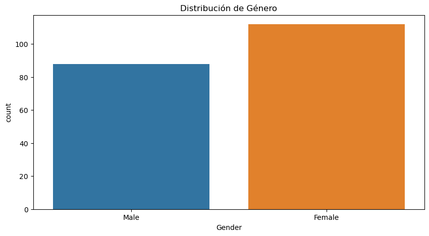

```python
# Distribución de Género
plt.figure(figsize=(10, 5))
sns.countplot(x='Gender', data=df)
plt.title('Distribución de Género')
plt.show()
```

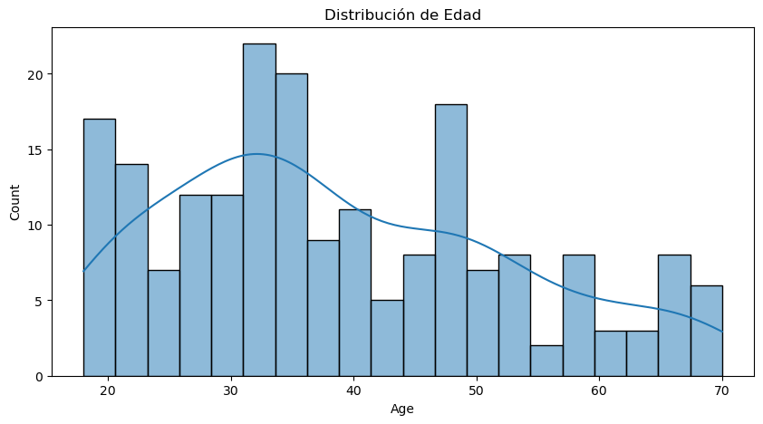

```python
# Distribución de Edad
plt.figure(figsize=(10, 5))
sns.histplot(df['Age'], bins=20, kde=True)
plt.title('Distribución de Edad')
plt.show()
```

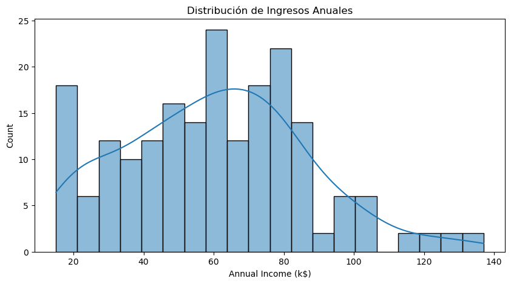

```python
# Distribución de Ingresos Anuales
plt.figure(figsize=(10, 5))
sns.histplot(df['Annual Income (k$)'], bins=20, kde=True)
plt.title('Distribución de Ingresos Anuales')
plt.show()
```

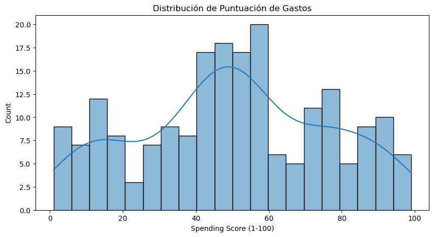

```python
# Distribución de Puntuación de Gastos
plt.figure(figsize=(10, 5))
sns.histplot(df['Spending Score (1-100)'], bins=20, kde=True)
plt.title('Distribución de Puntuación de Gastos')
plt.show()
```

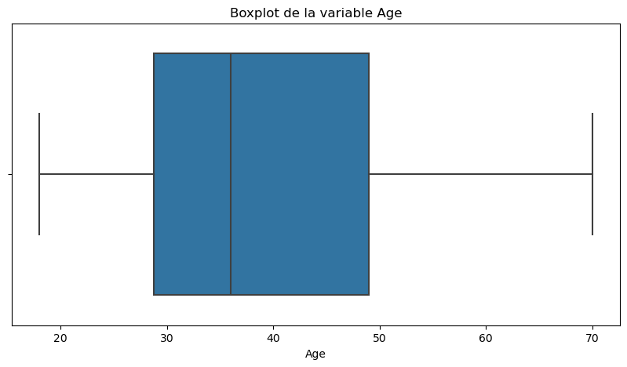

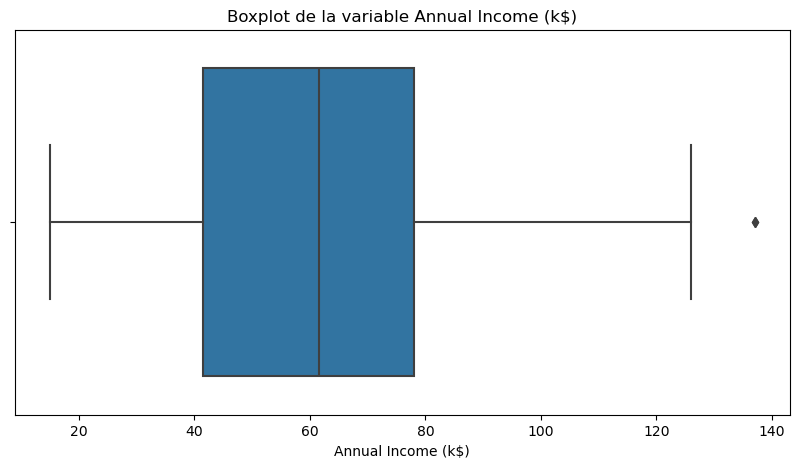

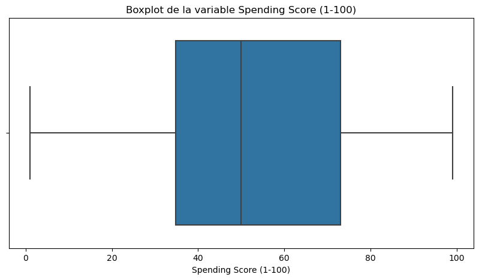

```python
# Boxplots de las variables numéricas
num_cols = ['Age', 'Annual Income (k$)', 'Spending Score (1-100)']
for col in num_cols:
    plt.figure(figsize=(10, 5))
    sns.boxplot(x=col, data=df)
    plt.title(f'Boxplot de la variable {col}')
    plt.show()
```

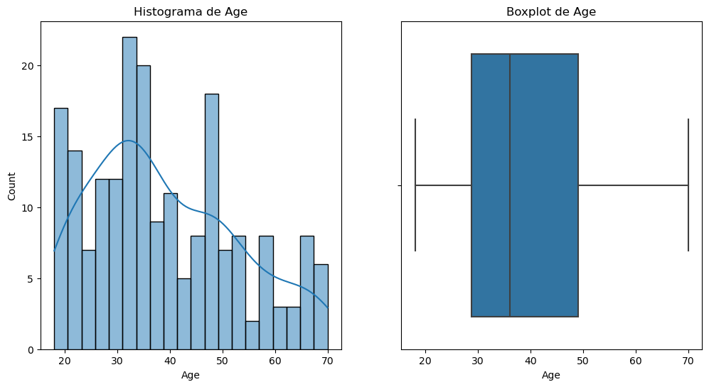

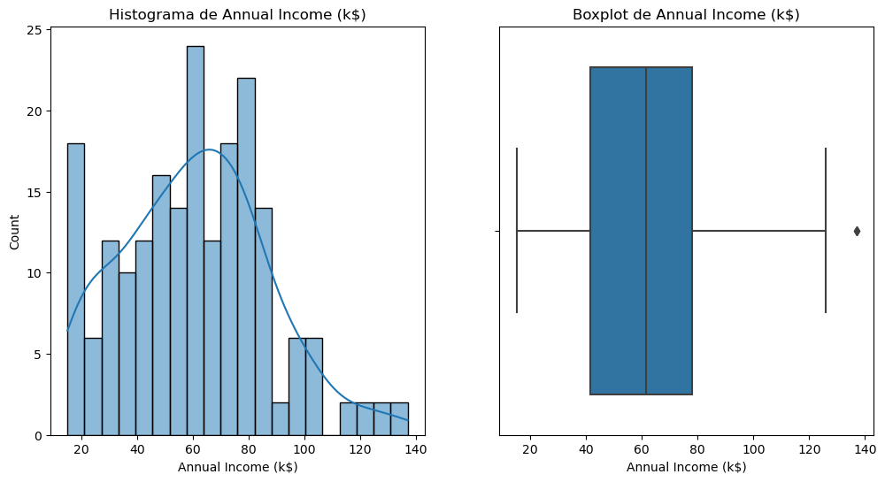

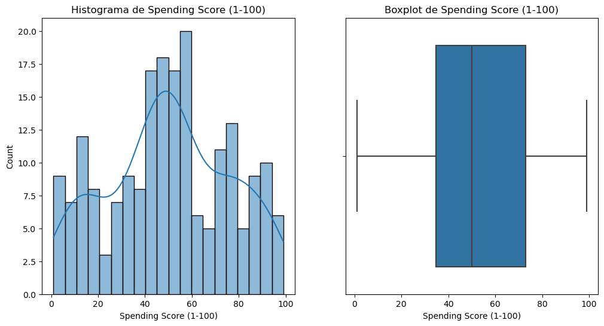

```python
# Convertir la variable categórica 'Gender' a numérica
df['Gender'] = df['Gender'].map({'Male': 0, 'Female': 1})

# Seleccionar las columnas numéricas
num_cols = ['Age', 'Annual Income (k$)', 'Spending Score (1-100)']

# Análisis univariado de cada variable numérica
for col in num_cols:
    plt.figure(figsize=(12, 6))

    # Histograma
    plt.subplot(1, 2, 1)
    sns.histplot(df[col], bins=20, kde=True)
    plt.title(f'Histograma de {col}')

    # Boxplot
    plt.subplot(1, 2, 2)
    sns.boxplot(x=df[col])
    plt.title(f'Boxplot de {col}')

    plt.show()
```

# 2. Preprocesamiento de Datos

```python
# Codificar la variable categórica 'Gender'
df['Gender'] = df['Gender'].map({'Male': 0, 'Female': 1})

# Seleccionar las características relevantes para el clustering
X = df[['Gender', 'Age', 'Annual Income (k$)', 'Spending Score (1-100)']]

# Escalar las características
from sklearn.preprocessing import StandardScaler
scaler = StandardScaler()
X_scaled = scaler.fit_transform(X)
```

# 3. K-means Clustering

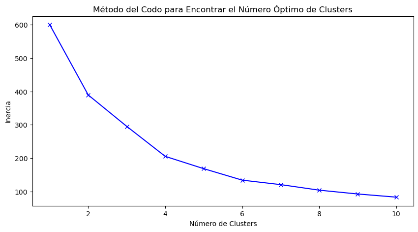

```python
from sklearn.impute import SimpleImputer
from sklearn.preprocessing import StandardScaler
from sklearn.cluster import KMeans
from sklearn.metrics import silhouette_score, calinski_harabasz_score

# Convertir la variable categórica 'Gender' a numérica
df['Gender'] = df['Gender'].map({'Male': 0, 'Female': 1})

# Seleccionar las características relevantes para el clustering
X = df[['Gender', 'Age', 'Annual Income (k$)', 'Spending Score (1-100)']]

# Imputar valores faltantes
imputer = SimpleImputer(strategy='mean')
X_imputed = imputer.fit_transform(X)

# Escalar las características
scaler = StandardScaler()
X_scaled = scaler.fit_transform(X_imputed)

# Encontrar el número óptimo de clusters usando el método del codo
inertia = []
K = range(1, 11)
for k in K:
    kmeans = KMeans(n_clusters=k, random_state=42)
    kmeans.fit(X_scaled)
    inertia.append(kmeans.inertia_)

plt.figure(figsize=(10, 5))
plt.plot(K, inertia, 'bx-')
plt.xlabel('Número de Clusters')
plt.ylabel('Inercia')
plt.title('Método del Codo para Encontrar el Número Óptimo de Clusters')
plt.show()

# Entrenar el modelo K-means con el número óptimo de clusters (por ejemplo, 5)
kmeans = KMeans(n_clusters=5, random_state=42)
kmeans.fit(X_scaled)

# Predecir los clusters
df['Cluster_KMeans'] = kmeans.labels_
```

# 4. Hierarchical Clustering

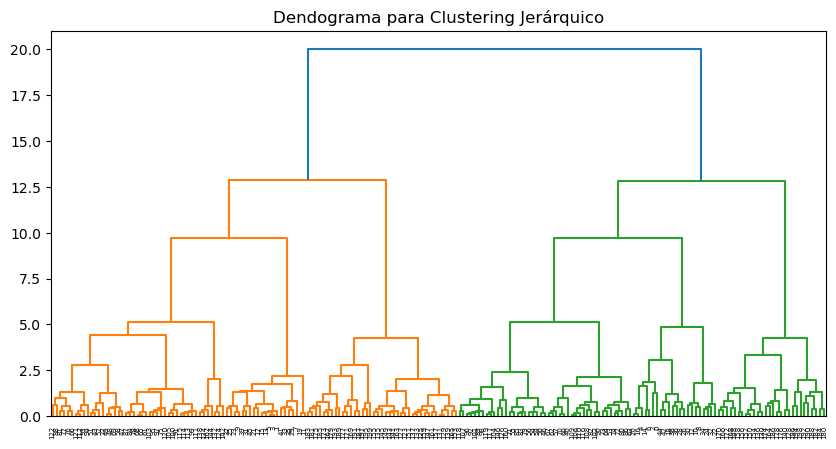

```python
from scipy.cluster.hierarchy import dendrogram, linkage
from sklearn.cluster import AgglomerativeClustering

# Calcular el dendograma
linked = linkage(X_scaled, method='ward')

plt.figure(figsize=(10, 5))
dendrogram(linked, orientation='top', distance_sort='descending', show_leaf_counts=True)
plt.title('Dendograma para Clustering Jerárquico')
plt.show()

# Entrenar el modelo de clustering jerárquico
hierarchical_clustering = AgglomerativeClustering(n_clusters=5, affinity='euclidean', linkage='ward')
df['Cluster_Hierarchical'] = hierarchical_clustering.fit_predict(X_scaled)
```

# 5. Evaluar el desempeño del modelo

### K-means Clustering

```python
# Evaluar el desempeño del modelo con el coeficiente de Silhouette y el índice de Calinski-Harabasz
silhouette_avg_kmeans = silhouette_score(X_scaled, kmeans.labels_)
calinski_harabasz_kmeans = calinski_harabasz_score(X_scaled, kmeans.labels_)
print('Coeficiente de Silhouette para K-means:', silhouette_avg_kmeans)
print('Índice de Calinski-Harabasz para K-means:', calinski_harabasz_kmeans)
```

```
Coeficiente de Silhouette para K-means: 0.41664341513732767
Índice de Calinski-Harabasz para K-means: 125.10094020060956
```

### Hierarchical Clustering

```python
# Evaluar el desempeño del modelo con el coeficiente de Silhouette y el índice de Calinski-Harabasz
silhouette_avg_hierarchical = silhouette_score(X_scaled, hierarchical_clustering.labels_)
calinski_harabasz_hierarchical = calinski_harabasz_score(X_scaled, hierarchical_clustering.labels_)
print('Coeficiente de Silhouette para Clustering Jerárquico:', silhouette_avg_hierarchical)
print('Índice de Calinski-Harabasz para Clustering Jerárquico:', calinski_harabasz_hierarchical)
```

```
Coeficiente de Silhouette para Clustering Jerárquico: 0.39002826186267214
Índice de Calinski-Harabasz para Clustering Jerárquico: 107.82656032570374
```

# 6. Visualización de los Resultados

### K-means Clustering

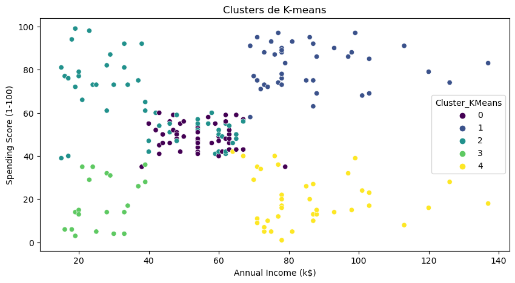

```python
plt.figure(figsize=(10, 5))
sns.scatterplot(x='Annual Income (k$)', y='Spending Score (1-100)', hue='Cluster_KMeans', data=df, palette='viridis')
plt.title('Clusters de K-means')
plt.show()
```

### Hierarchical Clustering

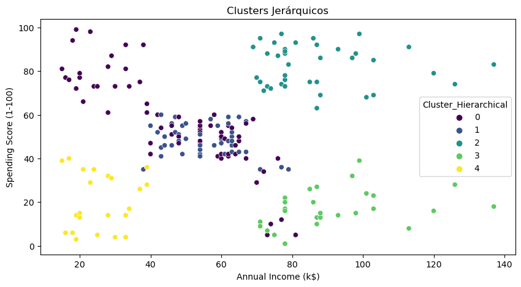

```python
plt.figure(figsize=(10, 5))
sns.scatterplot(x='Annual Income (k$)', y='Spending Score (1-100)', hue='Cluster_Hierarchical', data=df, palette='viridis')
plt.title('Clusters Jerárquicos')
plt.show()
```

# 7. Interpretación, Análisis y Documentación de Resultados

# Interpretación de los Resultados

## K-means Clustering

### Coeficiente de Silhouette:

- Un valor de 0.416 indica que los clusters están moderadamente bien formados.
- Este coeficiente mide la cohesión de los puntos dentro de los clusters y la separación entre los clusters. Un valor positivo cerca de 1 indica que los puntos están bien agrupados en sus propios clusters y están bien separados de los otros clusters.
- En este caso, aunque no es un valor extremadamente alto, es lo suficientemente bueno para indicar una separación razonable.

### Índice de Calinski-Harabasz:

- Un valor de 125.1 sugiere que hay una buena separación entre los clusters.
- Este índice evalúa la compacidad y la separación de los clusters, donde valores más altos indican una mejor formación de clusters.
- En comparación con el clustering jerárquico, el valor más alto de este índice indica que los clusters formados por K-means son más compactos y mejor separados.

### Gráfica de Clusters de K-means:

- La visualización muestra cinco clusters claramente diferenciados en términos de ingreso anual y puntuación de gastos.
- Los clusters están relativamente bien separados, con algunas áreas de superposición entre los puntos de diferentes clusters, especialmente en el rango medio de ingreso anual y puntuación de gastos.

## Hierarchical Clustering

### Coeficiente de Silhouette:

- Un valor de 0.390 indica una calidad de clustering moderada a baja.
- Este valor es ligeramente inferior al de K-means, lo que sugiere que los clusters no están tan bien definidos como en el modelo K-means.

### Índice de Calinski-Harabasz:

- Un valor de 107.8, que es menor que el de K-means, sugiere que los clusters formados no están tan bien separados.
- Esto indica que, aunque los clusters tienen cierta estructura, no están tan compactos ni bien definidos como los formados por K-means.

### Gráfica de Clusters Jerárquicos:

- La visualización también muestra cinco clusters.
- La separación entre algunos clusters no es tan clara como en K-means, y hay una mayor superposición entre puntos de diferentes clusters.

# Análisis Comparativo

## Conclusión:

- Basado en los coeficientes de evaluación y las visualizaciones, K-means parece ser un mejor método para este dataset en particular, proporcionando clusters más compactos y mejor definidos.
- Hierarchical Clustering ofrece una estructura alternativa, pero con una calidad de clustering ligeramente inferior según los índices evaluados.

# Documentación de Resultados

## Análisis Exploratorio:

- Las variables "Annual Income (k$)" y "Spending Score (1-100)" son críticas para la segmentación de clientes.
- La distribución de datos muestra una variedad razonable de ingresos y puntuaciones de gasto.

## Preprocesamiento:

- Se imputaron los valores faltantes utilizando la media de cada columna.
- Los datos fueron estandarizados para asegurar una escala uniforme en todas las características.

## Evaluación de Modelos:

- K-means obtuvo mejores resultados tanto en el coeficiente de Silhouette como en el índice de Calinski-Harabasz, sugiriendo una mejor definición y separación de los clusters.

## Conclusión:

- El modelo K-means es más adecuado para segmentar los clientes del dataset "Mall_Customers" debido a su mejor desempeño en las métricas de evaluación y visualización de clusters.
- Este análisis proporciona una base sólida para la interpretación de los resultados obtenidos y sugiere que K-means es una herramienta más eficaz para la segmentación de clientes en este contexto.